# Web scraping

Julian Flowers

2019-04-09

This vignette illustrates some of the basics of web-scraping and some features of the `myScrapers` package - in particular simple web-scraping functions. We also show some functions in the package specifically designed to retrieve public health information for public health practitioners.

## Web scraping basics in R

The basic toolkit is:

- a Url (link) you want to obtain data from
- the `rvest` package in R or `beautiful soup` in Python
- the [selector gadget](https://selectorgadget.com/) extension for web browsers

A basic knowledge of html is helpful - especially elements and tags. For example paragraphs are defined with the `<p>` tag, links with the `<a>` tag and so on. (“https://www.w3schools.com/html/html_intro.asp”)`

Selectorgadget enables finding tags used in style sheets if page layout is more sophisticated.

## Installing the package

The package is only available on Github and can be downloaded using `devtools`.

```r
library(devtools)
devtools::install_github("julianflowers/myScrapers")
```

## Simple web-scraping

Web scraping is a set of techniques to obtain information or data from websites. In R the `rvest` and `httr` packages are the mainstay of scraping (there is also `Rcrawler`). These import and read html and xml pages into R which can then be parsed and analysed.

In Python `beautiful soup` is the main package for web scraping.

Both are built on top of web commands which underpin the exchange of information across the internet.

In R, given any weblink or url we can read the site with the `GET` function in `httr`.

Lets use https:\\fingertips.phe.org.uk…

```r
url <- "https://fingertips.phe.org.uk"

html <- GET(url)

html
```

```
#> Response [https://fingertips.phe.org.uk/]
#>   Date: 2019-04-09 16:11
#>   Status: 200
#>   Content-Type: text/html; charset=utf-8
#>   Size: 24.9 kB
#>
#>
#> <!DOCTYPE html>
#> <html lang="en-GB">
#> <head>
#>     <!--[if lte IE 9]>
#>     <script type="text/javascript">
#>         window.location = "/browser-not-supported";
#>     </script>
#> <![endif]-->
#> ...
```

```r
rvest <- read_html(url)
rvest
```

```
#> {xml_document}
#> <html lang="en-GB">
#> [1] <head>\n<!--[if lte IE 9]>\r\n    <script type="text/javascript">\r\ ...
#> [2] <body>\r\n    <nav class="navbar navbar-dark bg-inverse"><div class= ...
```

```r
rvest %>%
  html_nodes("a") %>%
  .[1] %>%
  html_attr("href")
```

```
#> [1] "https://www.gov.uk/government/organisations/public-health-england"
```

In `myScrapers` there are 4 primary functions built on these:

- `get_page_links` which identifies the links on a webpage
- `get_page_text` which extracts text from a webpage
- `get_page_docs` which identifies pdf or doc files on a page
- `get_page_csv` which finds csv files and spreadsheets on a page

## Examples

We can use `get_page_links` to extract information from following page of PHE statistical releases. https://www.gov.uk/government/statistics?departments%5B%5D=public-health-england

```r
url <- "https://www.gov.uk/government/statistics?departments%5B%5D=public-health-england"

get_page_links(url) %>%
  .[19:40]
```

```
#>  [1] "https://www.gov.uk/government/statistics.atom?departments%5B%5D=public-health-england&publication_filter_option=statistics"
#>  [2] "/government/statistics/norovirus-and-rotavirus-summary-of-surveillance-2018-to-2019"
#>  [3] "/government/collections/norovirus-guidance-data-and-analysis"
#>  [4] "/government/collections/rotavirus-guidance-data-and-analysis"
#>  [5] "/government/statistics/klebsiella-spp-bacteraemia-monthly-data-split-by-location-of-onset-by-nhs-trust"
#>  [6] "/government/collections/klebsiella-species-guidance-data-and-analysis"
#>  [7] "/government/statistics/p-aeruginosa-bacteraemia-monthly-data-split-by-location-of-onset-by-nhs-trust"
#>  [8] "/government/collections/pseudomonas-aeruginosa-guidance-data-and-analysis"
#>  [9] "/government/statistics/mssa-bacteraemia-monthly-data-by-nhs-acute-trust"
#> [10] "/government/collections/staphylococcus-aureus-guidance-data-and-analysis"
#> [11] "/government/statistics/mrsa-bacteraemia-monthly-data-by-attributed-clinical-commissioning-group"
#> [12] "/government/collections/staphylococcus-aureus-guidance-data-and-analysis"
#> [13] "/government/statistics/escherichia-coli-e-coli-bacteraemia-monthly-data-by-attributed-clinical-commissioning-group"
#> [14] "/government/collections/escherichia-coli-e-coli-guidance-data-and-analysis"
#> [15] "/government/statistics/clostridium-difficile-infection-monthly-data-by-nhs-acute-trust"
#> [16] "/government/collections/clostridium-difficile-guidance-data-and-analysis"
#> [17] "/government/statistics/mrsa-bacteraemia-monthly-data-by-post-infection-review-assignment"
#> [18] "/government/collections/staphylococcus-aureus-guidance-data-and-analysis"
#> [19] "/government/statistics/e-coli-bacteraemia-monthly-data-split-by-location-of-onset-by-ccg"
#> [20] "/government/collections/escherichia-coli-e-coli-guidance-data-and-analysis"
#> [21] "/government/statistics/p-aeruginosa-bacteraemia-monthly-data-split-by-location-of-onset-by-ccg"
#> [22] "/government/collections/pseudomonas-aeruginosa-guidance-data-and-analysis"
```

## Use cases

We’ll use [GP in hours syndromic surveillance](https://www.gov.uk/government/publications/gp-in-hours-weekly-bulletins-for-2018) data to illustrate further uses. This report “Monitors the number of people who visit their GP during surgery hours under the syndromic surveillance system.”

The system publishes weekly reports and spreadsheets - to obtain a year’s worth of these reports manually would require 104 separate downloads.

Using a webscraping approach this can be achieved in a few lines of code.

### Identifying reports

The code below identifies all the pdf reports on the page.

```r
urls <- "https://www.gov.uk/government/publications/gp-in-hours-weekly-bulletins-for-2018"

get_page_links(urls) %>%
  .[grepl("pdf$", .)] %>%
  head(10) %>%
  unique()
```

```
#> [1] "https://assets.publishing.service.gov.uk/government/uploads/system/uploads/attachment_data/file/768457/GPinHoursEngBulletin2018Wk52.pdf"
#> [2] "https://assets.publishing.service.gov.uk/government/uploads/system/uploads/attachment_data/file/768045/GPinHoursEngBulletin2018Wk51.pdf"
#> [3] "https://assets.publishing.service.gov.uk/government/uploads/system/uploads/attachment_data/file/766892/GPinHoursEngBulletin2018Wk50.pdf"
#> [4] "https://assets.publishing.service.gov.uk/government/uploads/system/uploads/attachment_data/file/764099/GPinHoursEngBulletin2018Wk49.pdf"
#> [5] "https://assets.publishing.service.gov.uk/government/uploads/system/uploads/attachment_data/file/762355/GPinHoursEngBulletin2018Wk48.pdf"
```

We can then use the `downloader` package to download the pdfs:

```r
## not run
library(downloader)

(get_page_links(urls) %>%
  .[grepl("pdf$", .)] %>%
  head(10) %>%
  unique() %>%
  purrr::map(., ~download(.x, destfile = basename(.x))))
```

## Identifying data (spreadsheet links)

We can take a similar approach to spreadsheets.

Having downloaded the reports or spreadsheets it is now straightforward to import them for further analysis.

```r
library(readxl)
files <- list.files(pattern = ".xls")

data <- purrr::map(files, ~(read_excel(.x,  sheet = "Local Authority", na = "*",
    skip = 4)))

head(data)
```

```
#> [[1]]
#> # A tibble: 151 x 27
#>    `ONS Upper Tier… `ONS Upper Tier… `PHE Centre Nam… `PHE Centre ODS…
#>    <chr>            <chr>            <chr>            <chr>
#>  1 E09000002        Barking and Dag… London           X25001AA
#>  2 E09000003        Barnet           London           X25001AA
#>  3 E09000004        Bexley           London           X25001AA
#>  4 E09000005        Brent            London           X25001AA
#>  5 E09000006        Bromley          London           X25001AA
#>  6 E09000007        Camden           London           X25001AA
#>  7 E09000008        Croydon          London           X25001AA
#>  8 E09000009        Ealing           London           X25001AA
#>  9 E09000010        Enfield          London           X25001AA
#> 10 E09000011        Greenwich        London           X25001AA
#> # … with 141 more rows, and 23 more variables: `PHE Region Names` <chr>,
#> #   `PHE Region ODS Code` <chr>, `Denominator Population` <dbl>, `Observed
#> #   number of cases...8` <chr>, `Rate per 100,000...9` <chr>,
#> #   SIR...10 <dbl>, `SIR CI...11` <chr>, `Historic SIR...12` <chr>,
#> #   `Observed number of cases...13` <chr>, `Rate per 100,000...14` <chr>,
#> #   SIR...15 <dbl>, `SIR CI...16` <chr>, `Historic SIR...17` <chr>,
#> #   `Observed number of cases...18` <chr>, `Rate per 100,000...19` <chr>,
#> #   SIR...20 <dbl>, `SIR CI...21` <chr>, `Historic SIR...22` <chr>,
#> #   `Observed number of cases...23` <chr>, `Rate per 100,000...24` <chr>,
#> #   SIR...25 <dbl>, `SIR CI...26` <chr>, `Historic SIR...27` <chr>
#>
#> [[2]]
#> # A tibble: 151 x 27
#>    `ONS Upper Tier… `ONS Upper Tier… `PHE Centre Nam… `PHE Centre ODS…
#>    <chr>            <chr>            <chr>            <chr>
#>  1 E09000002        Barking and Dag… London           X25001AA
#>  2 E09000003        Barnet           London           X25001AA
#>  3 E09000004        Bexley           London           X25001AA
#>  4 E09000005        Brent            London           X25001AA
#>  5 E09000006        Bromley          London           X25001AA
#>  6 E09000007        Camden           London           X25001AA
#>  7 E09000008        Croydon          London           X25001AA
#>  8 E09000009        Ealing           London           X25001AA
#>  9 E09000010        Enfield          London           X25001AA
#> 10 E09000011        Greenwich        London           X25001AA
#> # … with 141 more rows, and 23 more variables: `PHE Region Names` <chr>,
```

[output cut: 69 more lines]

```
#>  6 E09000007        Camden           London           X25001AA
#>  7 E09000008        Croydon          London           X25001AA
#>  8 E09000009        Ealing           London           X25001AA
#>  9 E09000010        Enfield          London           X25001AA
#> 10 E09000011        Greenwich        London           X25001AA
#> # … with 141 more rows, and 23 more variables: `PHE Region Names` <chr>,
#> #   `PHE Region ODS Code` <chr>, `Denominator Population` <dbl>, `Observed
#> #   number of cases...8` <chr>, `Rate per 100,000...9` <chr>,
#> #   SIR...10 <chr>, `SIR CI...11` <chr>, `Historic SIR...12` <chr>,
#> #   `Observed number of cases...13` <chr>, `Rate per 100,000...14` <chr>,
#> #   SIR...15 <chr>, `SIR CI...16` <chr>, `Historic SIR...17` <chr>,
#> #   `Observed number of cases...18` <chr>, `Rate per 100,000...19` <chr>,
#> #   SIR...20 <chr>, `SIR CI...21` <chr>, `Historic SIR...22` <chr>,
#> #   `Observed number of cases...23` <chr>, `Rate per 100,000...24` <chr>,
#> #   SIR...25 <chr>, `SIR CI...26` <chr>, `Historic SIR...27` <chr>
```

## Scraping text

This follows the same principle. The function `get_page_text` is designed to extract text from a webpage. For example, we can extract the text from an article about Matt Hancock’s description of "predictive prevention’.

> October 6 2018, 12:01am, The Times, People’s medical records will be combined with social and smartphone data to predict who will pick up bad habits and stop them getting ill, under radical government proposals., Matt Hancock, the health secretary, is planning a system of “predictive prevention”, in which algorithms will use detailed data on individuals to send targeted healthy living messages to those flagged as having “propensities to health problems”, such as taking up smoking or becoming obese., Despite promises to safeguard data, the “creepy” plans have already attracted privacy concerns among doctors and campaigners, who say that the project risks backfiring by scaring people or damaging public trust in NHS handling of sensitive information.

## Analysing Duncan Selbie’s Friday messages

Using simple functions it is relatively easy to scrape Duncan Selbie’s blogs into a data frame for further analysis.

The base URL is https://publichealthmatters.blog.gov.uk/category/duncan-selbie-friday-message/, and there are 8 pages of results so the first task is to create a list of urls.

```r
url_ds <- "https://publichealthmatters.blog.gov.uk/category/duncan-selbie-friday-message/"
url_ds1 <- paste0(url_ds, "page/", 2:8)
urls_ds <- c(url_ds, url_ds1)
```

Then we can extract links and isolate those specific to the friday messages

```r
links <- purrr::map(urls_ds, ~(get_page_links(.x)))

friday_message <- links %>% purrr::flatten() %>%.[grepl("duncan-selbies-friday-message", .)] %>% .[!grepl("comments", .)] %>% unique()

head(friday_message)
```

```
#> [[1]]
#> [1] "https://publichealthmatters.blog.gov.uk/2019/04/05/duncan-selbies-friday-message-5-april-2019/"
#>
#> [[2]]
#> [1] "https://publichealthmatters.blog.gov.uk/2019/03/29/duncan-selbies-friday-message-29-march-2019/"
#>
#> [[3]]
#> [1] "https://publichealthmatters.blog.gov.uk/2019/03/22/duncan-selbies-friday-message-22-march-2019/"
#>
#> [[4]]
#> [1] "https://publichealthmatters.blog.gov.uk/2019/03/15/duncan-selbies-friday-message-15-march-2019/"
#>
#> [[5]]
#> [1] "https://publichealthmatters.blog.gov.uk/2019/03/08/duncan-selbies-friday-message-8-march/"
#>
#> [[6]]
#> [1] "https://publichealthmatters.blog.gov.uk/2019/03/01/duncan-selbies-friday-message-1-march-2019/"
```

and then extract blog text:

```r
library(tm)
library(magrittr)

blog_text <- purrr::map(friday_message, ~(get_page_text(.x)))
blog_text <- purrr::map(blog_text, ~(str_remove(.x, "\\n")))
blog_text <- purrr::map(blog_text, ~(str_remove(.x, "    GOV.UK blogs use cookies to make the site simpler. Find out more about cookies\n  ")))
blog_text <- purrr::map(blog_text, ~(str_remove(.x, "Dear everyone")))

blog_title <- purrr::map(blog_text, 2)
names(blog_text) <- blog_title

blog_text1 <- purrr::map(blog_text, extract, 5:11)
blog_text2 <- purrr::map(blog_text1, data.frame)
blog_text2 <- purrr::map_df(blog_text2, bind_rows)
blog_text2 <- blog_text2 %>% mutate(text = clean_texts(.x..i..))
```

We can then visualise with, for example, a wordcloud.

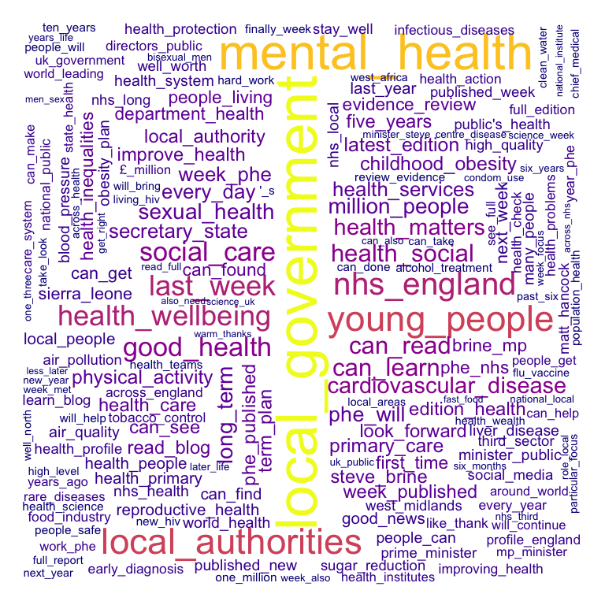

```r
library(quanteda)

corp <- corpus(blog_text2$text)
dfm <- dfm(corp, ngrams = 2, remove = c("government_licence", "open_government", "public_health", "official_blog", "blog_public", "health_england", "cancel_reply", "content available", "health_blog", "licence_v", "best_wishes", "otherwise_stated", "except_otherwise", "friday_messages", "best_wishes",
                                        "available_open"))

textplot_wordcloud(dfm, color = viridis::plasma(n = 10))
```

## Additional functions

I have added a few functions to the package.

`get_dsph_england` returns a list of local authorities and their current DsPH. It scrapes https://www.gov.uk/government/publications/directors-of-public-health-in-england--2/directors-of-public-health-in-england

```r
dsph <- get_dsph_england()
dsph %>%
  knitr::kable()
```

| LA | Name |
| --- | --- |
| Derby UA | Cate Edwynn |
| Derbyshire | Dean Wallace |
| Leicester UA | Ruth Tennant |
| Leicestershire | Mike Sandys |
| Lincolnshire | Derek Ward |
| Northamptonshire | Lucy Wightman |
| Nottingham UA | Alison Challenger |
| Nottinghamshire | Jonathan Gribbin |
| Rutland UA | Mike Sandys |
| Bedford Borough | Muriel Scott |
| Cambridgeshire | Liz Robin |
| Central Bedfordshire UA | Muriel Scott |
| Essex | Mike Gogarty |
| Hertfordshire | Jim McManus |
| Luton UA | Gerry Taylor |
| Milton Keynes UA | Muriel Scott |
| Norfolk (covers Great Yarmouth) | Louise Smith |
| Peterborough UA | Liz Robin |
| Southend on Sea UA | Andrea Atherton (Krishna Ramkhelawon covering until March 2019) |
| Suffolk (covers Waveney) | Amanda Jones (acting/Interim) |
| Thurrock UA | Ian Wake |
| Barking and Dagenham | Matthew Cole |
| Barnet | Tamara Djuretic |
| Bexley | Anjan Ghosh |
| Brent | Melanie Smith |
| Bromley | Nada Lemic |
| Camden | Julie Billet |
| City | Penny Bevan |
| Croydon | Rachel Flowers |
| Ealing | Wendy Meredith (acting/interim) |

[output cut: 122 more lines]

`get_phe_catalogue` identifies all the PHE publications on GOV.UK. For this function you have to set the n = argument. We recommend starting at n = 110. This produces an interactive searchable table of links.

```r
cat <- get_phe_catalogue(n=110)

cat
```

| Links | group | link |
| --- | --- | --- |
| https://www.gov.uk/government/statistics/clostridium-difficile-infection-monthly-data-by-nhs-acute-trust | statistics | Links |
| https://www.gov.uk/government/collections/clostridium-difficile-guidance-data-and-analysis | collections | Links |
| https://www.gov.uk/government/statistics/mrsa-bacteraemia-monthly-data-by-post-infection-review-assignment | statistics | Links |
| https://www.gov.uk/government/collections/staphylococcus-aureus-guidance-data-and-analysis | collections | Links |
| https://www.gov.uk/government/statistics/e-coli-bacteraemia-monthly-data-split-by-location-of-onset-by-ccg | statistics | Links |
| https://www.gov.uk/government/collections/escherichia-coli-e-coli-guidance-data-and-analysis | collections | Links |
| https://www.gov.uk/government/statistics/p-aeruginosa-bacteraemia-monthly-data-split-by-location-of-onset-by-ccg | statistics | Links |
| https://www.gov.uk/government/collections/pseudomonas-aeruginosa-guidance-data-and-analysis | collections | Links |
| https://www.gov.uk/government/statistics/e-coli-bacteraemia-monthly-data-split-by-location-of-onset-by-nhs-trust | statistics | Links |
| https://www.gov.uk/government/statistics/mssa-bacteraemia-monthly-data-by-attributed-clinical-commissioning-group | statistics | Links |

[output cut: 4243 more lines]

## Reviewing parliamentary questions (PQs)

We have added a `get_pq` function built on the `hansard` package to extract PQs addressed to, answered by or mentioning PHE. This takes a start date as an argument in the form yyyy-mm-dd.

```r
pqs <- get_pqs(start_date = "2019-03-01")
```

```
#> Please wait...
```

```r
pqs
```

```
#> # A tibble: 51 x 5
#>    answer_date question_text  answer_text answering_member hansard_category
#>    <chr>       <chr>          <chr>       <chr>            <chr>
#>  1 2019-04-08  To ask the Se… "The alloc… Seema Kennedy    Public Health: …
#>  2 2019-04-08  To ask the Se… "The alloc… Seema Kennedy    Public Health: …
#>  3 2019-04-09  To ask the Se… Public Hea… Seema Kennedy    Obesity
#>  4 2019-04-05  To ask the Se… "Public He… Jackie Doyle-Pr… Vaccination
#>  5 2019-04-05  To ask the Se… "The Depar… Jackie Doyle-Pr… Mortality Rates…
#>  6 2019-04-04  To ask the Se… "Public He… Jackie Doyle-Pr… Health: Children
#>  7 2019-04-05  To ask the Se… "Public He… Jackie Doyle-Pr… Alcoholic Drink…
#>  8 2019-04-02  To ask the Se… The Govern… Jackie Doyle-Pr… Health Services…
#>  9 2019-04-02  To ask the Se… "The Sunbe… Jackie Doyle-Pr… Skin Cancer: Su…
#> 10 2019-04-04  To ask the Se… "Public He… Jackie Doyle-Pr… Skin Cancer: Su…
#> # … with 41 more rows
```

We can look at the categories of questions asked.

```r
pqs %>%
  group_by(hansard_category) %>%
  count() %>%
  arrange(-n) %>%
  top_n(10)
```

```
#> # A tibble: 37 x 2
#> # Groups:   hansard_category [37]
#>    hansard_category                    n
#>    <chr>                           <int>
#>  1 Dialysis Machines                   5
#>  2 Obesity                             4
#>  3 Breast Cancer: Health Education     2
#>  4 Ehlers-Danlos Syndrome              2
#>  5 Electronic Cigarettes               2
#>  6 Lyme Disease                        2
#>  7 Public Health: Enfield              2
#>  8 Skin Cancer: Sunbeds                2
#>  9 Vaccination                         2
#> 10 5G: Health Hazards                  1
#> # … with 27 more rows
```

## Using `myScrapers` to extract NICE guidance

We can use the toolkit to extract NICE Public Health Guidance as follows:

- Firstly we’ll identify the URLs for NICE PH guidance - they related to https://www.nice.org.uk/guidance/published?type=ph
- Then create a full URL for recommendations
- Then extract the text

```r
url <- "https://www.nice.org.uk/guidance/published?type=ph"

links <- get_page_links(url)[13:22] ##first 10  sets of guidance
links1 <- purrr::map(links, ~(paste0("https://www.nice.org.uk", .x, "/chapter/Recommendations")))

pander::panderOptions("table.style", "multiline")
pander::panderOptions("table.alignment.default", "left")
recommendations <- purrr::map(links1, ~(get_page_text(.x))) %>% purrr::map(., data.frame)
head(recommendations, 1) %>%
  knitr::kable()
```

| .x..i.. |
| --- |
| NICE guideline [NG105] |

[output not shown]

[output not shown]